# Predict LendingClub’s Loan Data

# Synopsis

In this report, we attempt to predict the risk of the loan being default based on the past loan data. We obtained data from LendingClub’s website(https://www.lendingclub.com/info/download-data.action). We use loan data from year 2012-2014 as training and cross-validation set and loan data from year 2015 as a testing set. We also compare our investment performance against the baseline algorithm. We found that, among multiple machine learning algorithms that we tried, Logistic Regression provided a reasonable trade-off performance, and a higher return than the naive loan picking strategy can be achieved.

# Explore Data

The loan dataset can be downloaded from https://www.lendingclub.com/info/download-data.action. We renamed the file of 2012-2013 loan data to `loan_2012_2013.csv`, 2014 loan data to `loan_2014.csv` and 2015 loan data to `loan_2015.csv`. We stored them on the same directory of the script. The data dictionary can be found at the same URL.

There are 7 loan statuses: `Charged Off`,`Current`,`Default`,`Fully Paid`,`In Grace Period`,`Late (16-30 days)`,`Late (31-120 days)`. We consider `Late (31-120 days)`, `Default`, `Charged Off` as a default loan and `Fully Paid` as a desirable loan and ignore everything else. We can create a shell script to filter such loan instead of loading the entire files.

We create extract.sh to perform the task:

```
#!/bin/sh

input_file=$1
output_file=$2
sed '2!d' $input_file > $output_file
awk -F '","'  'BEGIN {OFS=","} { if (toupper($17) == "FULLY PAID" || toupper($17) == "LATE (31-120 DAYS)" || toupper($17) == "DEFAULT" || toupper($17) == "CHARGED OFF")  print }' $input_file >> $output_file
```

Execute the following command in the command line to filter only target statuses:

```
sh extract.sh loan_2012_2013.csv loan_2012_2013.extract.csv
sh extract.sh loan_2014.csv loan_2014.extract.csv
sh extract.sh loan_2015.csv loan_2015.extract.csv
```

We can now use *.extract.csv as our dataset

```r
#load all required package
library(dplyr)
library(ggplot2)
library(caret)
library(rpart)
library(rpart.plot)
library(randomForest)
library(corrplot)
library(e1071)
library(xgboost)
library(stringr)
library(lubridate)
library(tm)
library(rms)
library(glmnet)
library(pROC)
library(doMC)
library(kernlab)
#make the analysis reproducible
set.seed(100)

setwd(".")
```

We firstly investigate overall data

```r
data_a = read.csv("loan_2012_2013.extract.csv",stringsAsFactors=FALSE)
data_b = read.csv("loan_2014.extract.csv",stringsAsFactors=FALSE)
data = read.csv("loan_2015.extract.csv",stringsAsFactors=FALSE)
data = rbind(data,data_a,data_b)
rm(data_a,data_b)
```

We take a look at the number of each loan_status so far

```r
data %>% group_by(loan_status) %>% summarise(count = n())
```

```
## Source: local data frame [4 x 2]
##
##          loan_status  count
##                <chr>  <int>
## 1        Charged Off  57896
## 2            Default    203
## 3         Fully Paid 242869
## 4 Late (31-120 days)  12665
```

We categorize `Charged Off`, `Default`, and `Late (31-120 days)` to a single category: `Default`. The data is moderately imbalance.

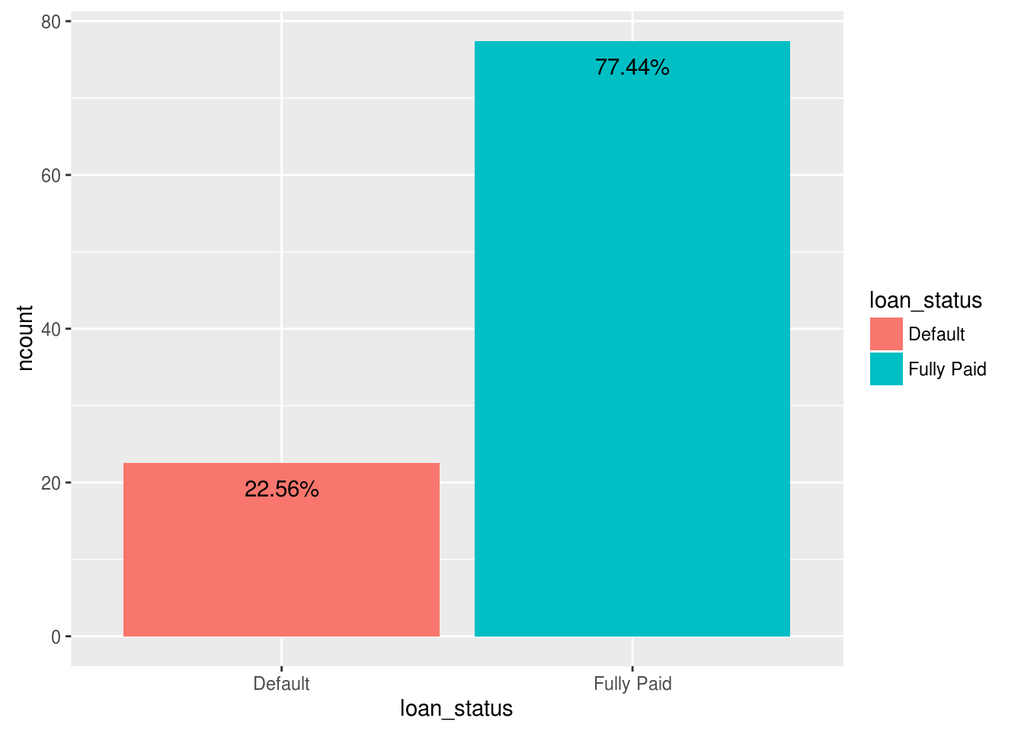

```r
data$loan_status = ifelse(str_detect(data$loan_status,"Paid"),data$loan_status,"Default")

tmp = data %>% group_by(loan_status) %>% summarise(ncount = n())
tmp$ncount = 100 * tmp$ncount/nrow(data)
tmp$ncount_p = str_c(round(tmp$ncount,2),"%")
ggplot(tmp,aes(x=loan_status,y=ncount,fill=loan_status)) + geom_bar(stat="identity") +
    geom_text(aes(label=ncount_p),vjust = 2)
```

# Problem Formulation

The goal of this analysis is to produce a loan picking strategy that is superior to the naive one. Let’s look at the return and default rate for each loan grade from 2012-2015.

```r
data$int_rate = (as.numeric(gsub(pattern = "%",replacement = "",x = data$int_rate)))
#extract issued year
data$issue_y = as.numeric(sapply( data$issue_d ,function(x){str_split(x,"-")[[1]][2]}))

displayInterestByGrade <- function(dt){
    g1 = dt %>% filter(loan_status == "Default") %>% group_by(grade) %>% summarise(default_count = n())
    g2 = dt %>% group_by(grade) %>% summarise(count = n(),int_rate=mean(int_rate))
    g2 %>% left_join(g1) %>% mutate(default_rate = 100*default_count/count) %>% select(grade,count,default_count,int_rate,default_rate)
}

#year 2012
tmp0 = displayInterestByGrade(data %>% filter(issue_y==2012))
tmp0$year = 2012
#year 2013
tmp1 = displayInterestByGrade(data %>% filter(issue_y==2013))
tmp1$year = 2013
#year 2014
tmp2 = displayInterestByGrade(data %>% filter(issue_y==2014))
tmp2$year = 2014
#year 2015
tmp3 = displayInterestByGrade(data %>% filter(issue_y==2015))
```

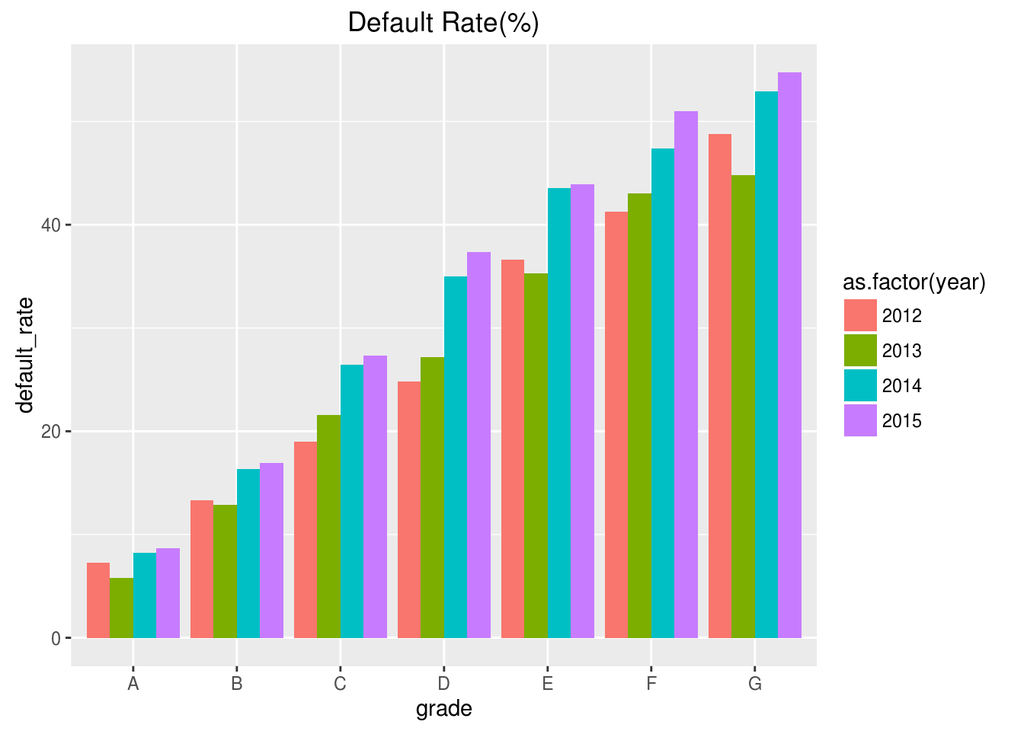

```r
tmp3$year = 2015
tmp = rbind(tmp0,tmp1,tmp2,tmp3)

ggplot(tmp, aes(x=grade, y=default_rate,fill=as.factor(year))) + geom_bar(stat="identity",position="dodge") + ggtitle("Default Rate(%)")
```

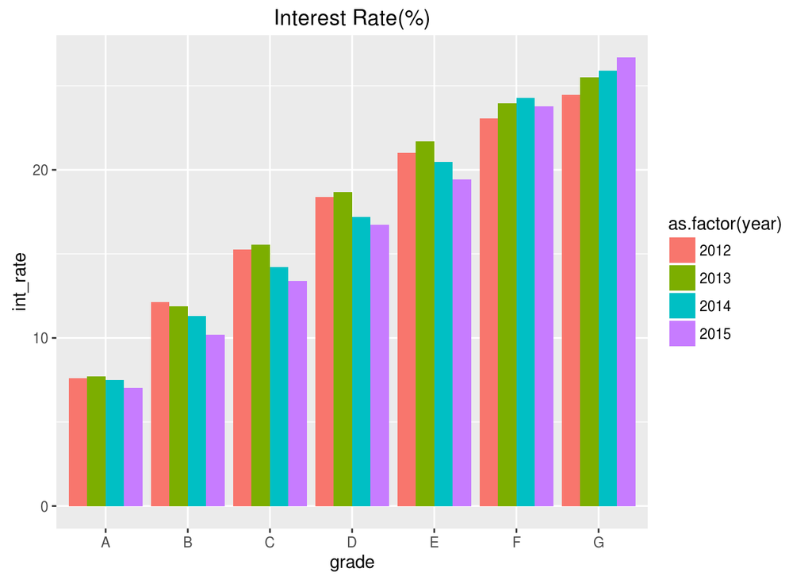

```r
ggplot(tmp, aes(x=grade, y=int_rate,fill=as.factor(year))) + geom_bar(stat="identity",position="dodge") + ggtitle("Interest Rate(%)")
```

```r
rm(tmp,tmp0,tmp1,tmp2,tmp3)
```

As expected, riskier loans come with higher interest rates.

We can use `total_pymnt`(payment obtained from borrower) and `funded_amnt`(money lent) to calculate Return on Investment(ROI).

For year 2015, the ROI of our baseline investment strategy-Picking every loans-, is:

```r
all_roi = sum((data %>% filter(issue_y==2015))$total_pymnt)/sum((data %>% filter(issue_y==2015))$funded_amnt) - 1
all_roi
```

```
## [1] -0.1756042
```

or roughly -17.56%. Noted that we excluded `Current` loans from our analysis(which a large amount of them typically ended up being paid-off), so negative ROI is as expected. Again, the higher the ROI is, the better.

We can look at ROI pertaining to each loan grade:

```r
data$prediction = "Fully Paid"
createPerformanceTable <- function(dt){

    dt_pick = dt %>% filter(prediction == "Fully Paid")
    all_roi = sum(dt_pick$total_pymnt)/sum(dt_pick$funded_amnt) - 1

    temp_table = data.frame(grade=character(0),roi=numeric(0),percent_pick=numeric(0))
    for(g in c("A","B","C","D","E","F","G")){
        data_pick_grade = dt_pick %>% filter(grade==g)
        if(nrow(data_pick_grade)==0){
            temp_table = rbind(temp_table,data.frame(grade=g,roi=0,percent_pick=0))
        }
        else
        {
            data_grade = dt %>% filter(grade==g)
            roi = sum(data_pick_grade$total_pymnt)/sum(data_pick_grade$funded_amnt) - 1
            temp_table = rbind(temp_table,data.frame(grade=g,roi=roi,percent_pick=100 * nrow(data_pick_grade)/nrow(data_grade)))
        }
    }

    temp_table = rbind(temp_table,data.frame(grade="ALL",roi=all_roi,percent_pick=100 * nrow(dt_pick)/nrow(dt) ))

    return(temp_table)
}

baseline_table = createPerformanceTable(data %>% filter(issue_y==2015))
baseline_table
```

```
##   grade         roi percent_pick
## 1     A -0.02860544          100
## 2     B -0.08447862          100
## 3     C -0.16181754          100
## 4     D -0.23565662          100
## 5     E -0.28144831          100
## 6     F -0.34315720          100
## 7     G -0.35786380          100
## 8   ALL -0.17560423          100
```

The `baseline_table` served as a baseline performance when we evaluate our model

# Model Building Strategy

2012-2014 data will be served as training & cross validation set and 2015 as a test set. We will put more emphasis on avoiding **default** loans since they can wreak havoc on our overall investment. We also take a note of percentage of loan picked as picking a small number of loans doesn’t make a sizable investment.

# Feature Engineering

We explore some features in the dataset. We will create transformation model for the 2012-2014 data. We will later apply it to 2015 data.

```r
data1 = data %>% filter(issue_y != 2015)
#look at number of row and column
dim(data1)
```

```
## [1] 246073    113
```

```r
rm(data)
```

Looking at the data dictionary, we can identify and drop irrelevant features(features that do not appear at the issued time, or id field). `emp_title` may be useful but it needed to be effectively categorized.

```r
discard_column = c("collection_recovery_fee","emp_title",
                   "funded_amnt_inv","id",
                   "installment","last_credit_pull_d",
                   "last_fico_range_high","last_fico_range_low",
                   "last_pymnt_amnt","last_pymnt_d",
                   "loan_amnt","member_id",
                   "next_pymnt_d","num_tl_120dpd_2m",
                   "num_tl_30dpd","out_prncp",
                   "out_prncp_inv","recoveries",
                   "total_pymnt","total_pymnt_inv",
                   "total_rec_int","total_rec_late_fee",
                   "total_rec_prncp","url",
                   "zip_code"
                   )

data1 = (data1[,!(names(data1) %in% discard_column)])
```

We also drop `grade` featrue as such data also carried in `sub_grade`

```r
data1$grade = NULL
```

We drop features that contain too many NA values. We can list the raito of `NA` value for each feature:

```r
tmp = sort(sapply(data1, function(x) sum(length(which(is.na(x)))))/nrow(data1),decreasing = TRUE)
```

Drop features that have more than 50% missing and take a look at what features that are still missing:

```r
discard_column = names(tmp[tmp>0.5])
data1 = (data1[,!(names(data1) %in% discard_column)])

tmp = sort(sapply(data1, function(x) sum(length(which(is.na(x)))))/nrow(data1),decreasing = TRUE)
tmp[tmp>0]
```

```
##         mo_sin_old_il_acct      mths_since_recent_inq
##                 0.13758925                 0.11994815
##             pct_tl_nvr_dlq                avg_cur_bal
##                 0.10749656                 0.10719177
##       mo_sin_old_rev_tl_op      mo_sin_rcnt_rev_tl_op
##                 0.10715113                 0.10715113
##               tot_coll_amt                tot_cur_bal
##                 0.10714707                 0.10714707
##           total_rev_hi_lim             mo_sin_rcnt_tl
##                 0.10714707                 0.10714707
##      num_accts_ever_120_pd             num_actv_bc_tl
##                 0.10714707                 0.10714707
##            num_actv_rev_tl                  num_bc_tl
##                 0.10714707                 0.10714707
##                  num_il_tl              num_op_rev_tl
##                 0.10714707                 0.10714707
##              num_rev_accts        num_rev_tl_bal_gt_0
##                 0.10714707                 0.10714707
##         num_tl_90g_dpd_24m         num_tl_op_past_12m
##                 0.10714707                 0.10714707
##            tot_hi_cred_lim total_il_high_credit_limit
##                 0.10714707                 0.10714707
##                num_bc_sats                   num_sats
##                 0.06212384                 0.06212384
##                    bc_util           percent_bc_gt_75
##                 0.03882994                 0.03843168
##             bc_open_to_buy       mths_since_recent_bc
##                 0.03821630                 0.03720441
##       acc_open_past_24mths                   mort_acc
##                 0.02899952                 0.02899952
##          total_bal_ex_mort             total_bc_limit
##                 0.02899952                 0.02899952
```

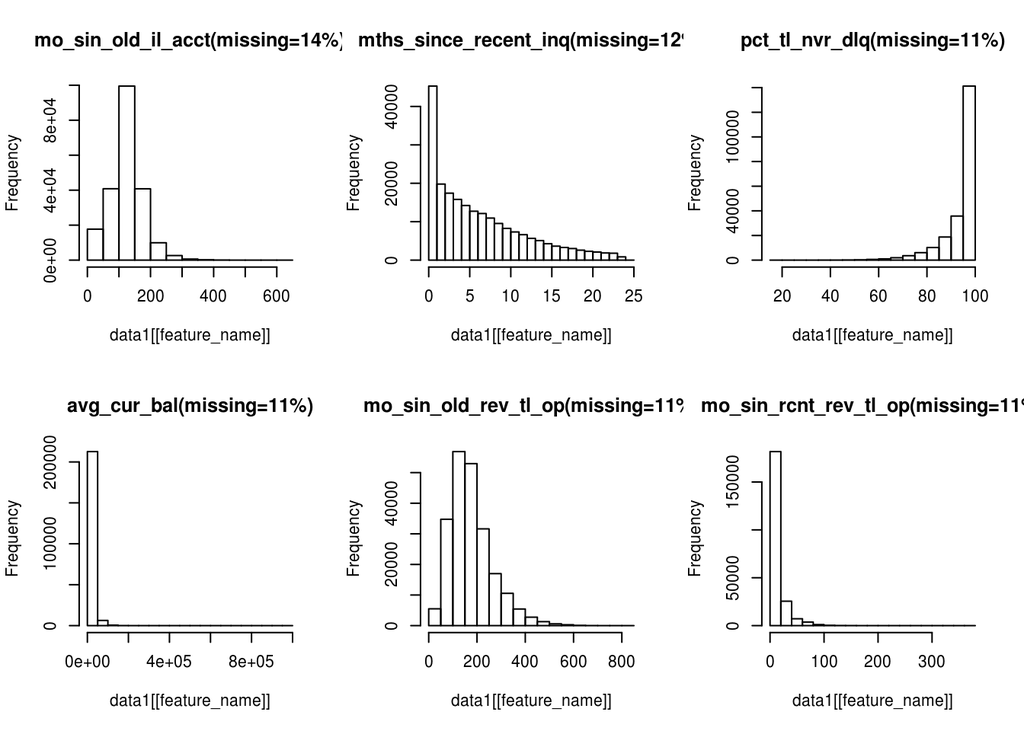

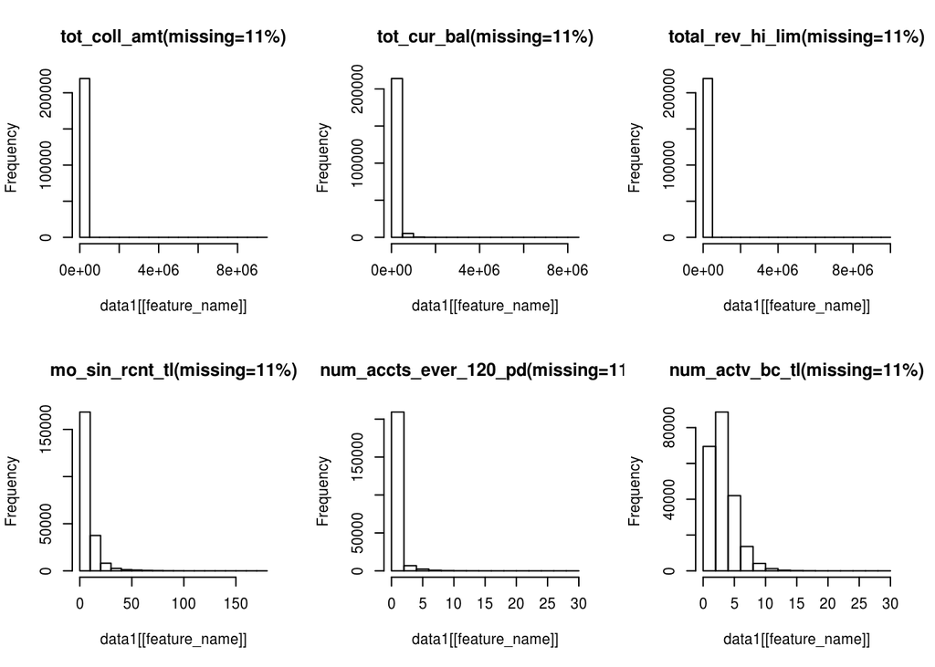

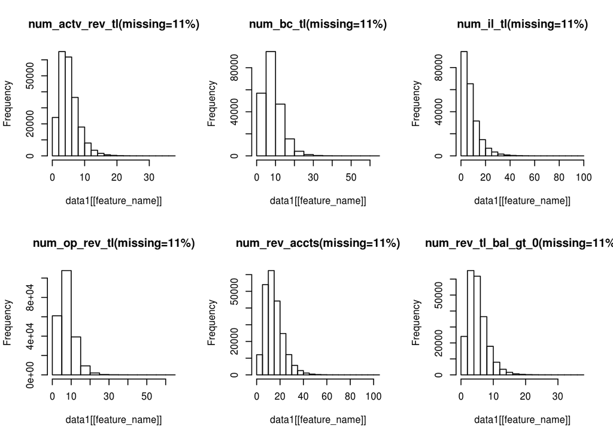

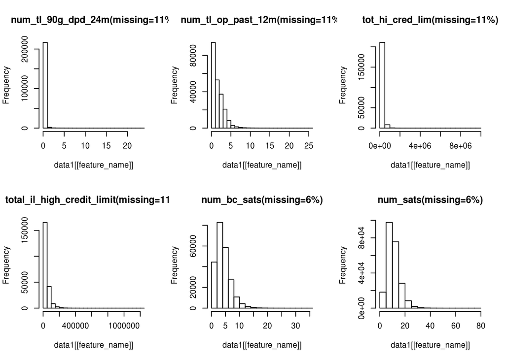

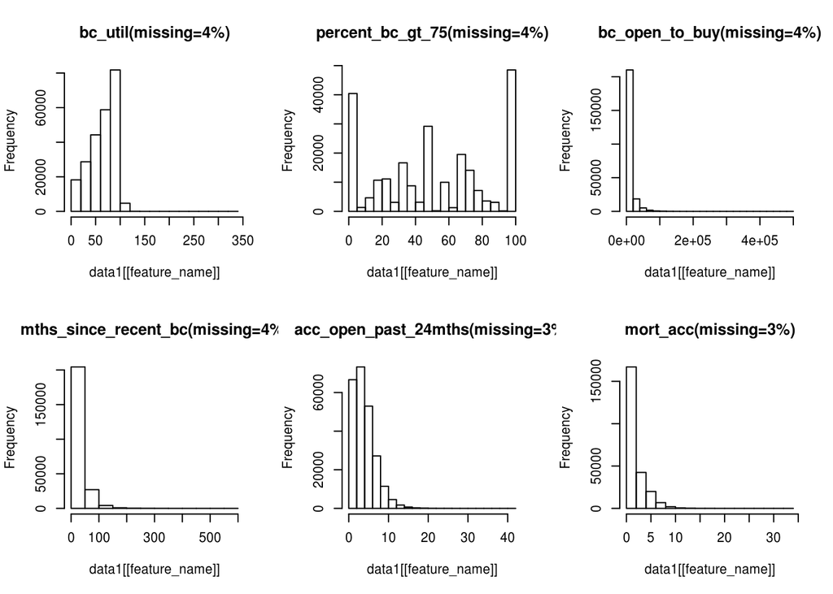

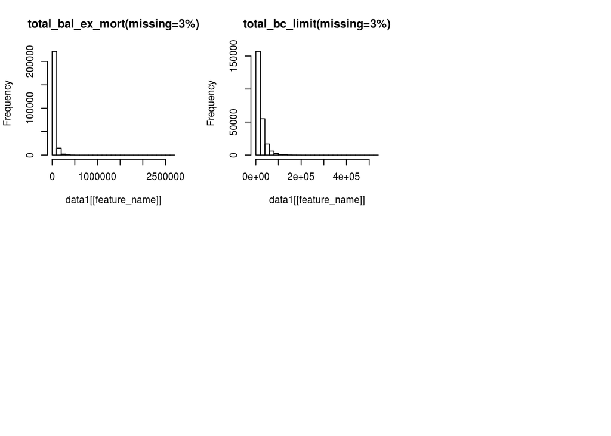

```r
tmp = tmp[tmp>0]

par(mfrow=c(2,3))
for(feature_name in names(tmp)){
    hist(data1[[feature_name]],main = str_c(feature_name,"(missing=",100* round(as.numeric(tmp[feature_name]),2) ,"%)") )
}
```

```r
par(mfrow=c(1,1))
```

From the look of distributions, it is reasonable to impute missing values with the median value. We store `median_impute_model` for further use.

```r
median_impute_model = preProcess(data1[names(tmp)],method="medianImpute")
data1 = predict(median_impute_model,data1)
```

Let’s re-check the columns left, there should be no feature with NA value

```r
sort(sapply(data1, function(x) sum(length(which(is.na(x)))))/nrow(data1),decreasing = TRUE)
```

```
##                funded_amnt                       term
##                          0                          0
##                   int_rate                  sub_grade
##                          0                          0
##                 emp_length             home_ownership
##                          0                          0
##                 annual_inc        verification_status
##                          0                          0
##                    issue_d                loan_status
##                          0                          0
##                 pymnt_plan                       desc
##                          0                          0
##                    purpose                      title
##                          0                          0
##                 addr_state                        dti
##                          0                          0
##                delinq_2yrs           earliest_cr_line
##                          0                          0
##             inq_last_6mths                   open_acc
##                          0                          0
##                    pub_rec                  revol_bal
##                          0                          0
##                 revol_util                  total_acc
##                          0                          0
##        initial_list_status collections_12_mths_ex_med
##                          0                          0
##                policy_code           application_type
##                          0                          0
##             acc_now_delinq               tot_coll_amt
##                          0                          0
##                tot_cur_bal           total_rev_hi_lim
##                          0                          0
##       acc_open_past_24mths                avg_cur_bal
##                          0                          0
##             bc_open_to_buy                    bc_util
##                          0                          0
##   chargeoff_within_12_mths                delinq_amnt
##                          0                          0
##         mo_sin_old_il_acct       mo_sin_old_rev_tl_op
##                          0                          0
```

[output cut: 13 more lines]

```
##                          0                          0
##                   num_sats         num_tl_90g_dpd_24m
##                          0                          0
##         num_tl_op_past_12m             pct_tl_nvr_dlq
##                          0                          0
##           percent_bc_gt_75       pub_rec_bankruptcies
##                          0                          0
##                  tax_liens            tot_hi_cred_lim
##                          0                          0
##          total_bal_ex_mort             total_bc_limit
##                          0                          0
## total_il_high_credit_limit                    issue_y
##                          0                          0
##                 prediction
##                          0
```

Let’s take a look at all features left

```r
str(data1)
```

```
## 'data.frame':    246073 obs. of  67 variables:
##  $ funded_amnt               : int  20800 3000 12000 12000 28000 11100 8000 24000 15000 12000 ...
##  $ term                      : chr  " 36 months" " 36 months" " 36 months" " 36 months" ...
##  $ int_rate                  : num  13.53 12.85 13.53 7.62 7.62 ...
##  $ sub_grade                 : chr  "B5" "B4" "B5" "A3" ...
##  $ emp_length                : chr  "10+ years" "10+ years" "10+ years" "3 years" ...
##  $ home_ownership            : chr  "RENT" "RENT" "RENT" "MORTGAGE" ...
##  $ annual_inc                : num  81500 25000 40000 96500 325000 90000 33000 100000 98000 60000 ...
##  $ verification_status       : chr  "Verified" "Verified" "Source Verified" "Not Verified" ...
##  $ issue_d                   : chr  "Dec-2013" "Dec-2013" "Dec-2013" "Dec-2013" ...
##  $ loan_status               : chr  "Fully Paid" "Fully Paid" "Fully Paid" "Fully Paid" ...
##  $ pymnt_plan                : chr  "n" "n" "n" "n" ...
##  $ desc                      : chr  "  Borrower added on 12/31/13 > My goal is to purchase a home. I am consolidating my debt to lower interest rate to pay off debt"| __truncated__ "" "" "  Borrower added on 12/31/13 > Bought a new house, furniture, water softener, a second car, etc. Got our live…
##  $ purpose                   : chr  "debt_consolidation" "debt_consolidation" "debt_consolidation" "debt_consolidation" ...
##  $ title                     : chr  "Reducing Debt to Purchase Home" "debt" "Debt consolidation" "Debt Consolidation and Credit Transfer" ...
```

[output cut: 53 more lines]

We parse revol_util to numeric

```r
data1$revol_util = (as.numeric(gsub(pattern = "%",replacement = "",x = data1$int_rate)))
```

`earliest_cr_line` is transformed to the number of days before the loan is issued

```r
data1$earliest_cr_line = parse_date_time(str_c("01",data1$issue_d),"dmy" ) - parse_date_time(str_c("01",data1$earliest_cr_line),"dmy" )
data1$earliest_cr_line = as.numeric(data1$earliest_cr_line,units = "days")
```

We can see that the default rate doesn’t vary much by the month it issued. We will drop `issue_d`

```r
#extract issued month
data1$issue_m = sapply( data1$issue_d ,function(x){str_split(x,"-")[[1]][1]})

tmp = data1 %>% filter(loan_status=="Default") %>% group_by(issue_m) %>% summarise(default_count = n())
tmp2 = data1 %>% group_by(issue_m) %>% summarise(count = n())
tmp2 %>% left_join(tmp) %>% mutate(default_rate = default_count/count)
```

```
## Source: local data frame [12 x 4]
##
##    issue_m count default_count default_rate
##      <chr> <int>         <int>        <dbl>
## 1      Apr 20828          4134    0.1984828
## 2      Aug 20604          4592    0.2228693
## 3      Dec 17151          3452    0.2012711
## 4      Feb 17129          3391    0.1979684
## 5      Jan 17315          3356    0.1938204
## 6      Jul 24245          5663    0.2335739
## 7      Jun 20575          4230    0.2055893
## 8      Mar 18570          3599    0.1938072
## 9      May 21288          4357    0.2046693
## 10     Nov 22413          5007    0.2233971
## 11     Oct 28244          6553    0.2320139
## 12     Sep 17711          3714    0.2097002
```

```r
data1$issue_m = NULL
data1$issue_d = NULL

rm(tmp,tmp2)
```

Let’s see if there are any features that have zero variance:

```r
#define some functions to be used later on
getNumericColumns<-function(t){
    tn = sapply(t,function(x){is.numeric(x)})
    return(names(tn)[which(tn)])
}

getCharColumns<-function(t){
    tn = sapply(t,function(x){is.character(x)})
    return(names(tn)[which(tn)])
}

getFactorColumns<-function(t){
    tn = sapply(t,function(x){is.factor(x)})
    return(names(tn)[which(tn)])
}

getIndexsOfColumns <- function(t,column_names){
    return(match(column_names,colnames(t)))
}
```

```r
tmp = apply(data1[getCharColumns(data1)],2,function(x){length(unique(x))})
tmp = tmp[tmp==1]

tmp2 = apply(data1[getNumericColumns(data1)],2,function(x){(sd(x))})
tmp2 = tmp2[tmp2==0]

discard_column = c(names(tmp),names(tmp2))
discard_column
```

```
## [1] "application_type" "prediction"       "policy_code"
```

We then proceed to drop the zero variance features

```r
data1 = (data1[,!(names(data1) %in% discard_column)])
```

Next, we investigate whether `desc`(description) can be useful in determining Default and Fully Paid loan. However, noted that our test dataset(2015 loans) has only **9** loans with non-empty description’s length so `desc` is quite useless for current 2015 data. Also noted that information in `title` is replicated in `purpose` so we will drop them.

```r
data1$desc = NULL
data1$title = NULL
```

We take a look at default rate for each state from year 2012-2014. We filter out states that have too small number of loans(less than 1000):

```r
tmp = data1 %>% filter(loan_status=="Default") %>% group_by(addr_state,issue_y) %>% summarise(default_count = n())
tmp2 = data1 %>% group_by(addr_state,issue_y) %>% summarise(count = n())
tmp3 = tmp2 %>% left_join(tmp) %>% mutate(default_rate = default_count/count)
#order by highest default rate
a0 = (tmp3 %>% filter(issue_y == 2012 & count > 1000) %>% arrange(desc(default_rate)))[1:10,"addr_state"]$addr_state
a1 = (tmp3 %>% filter(issue_y == 2013 & count > 1000) %>% arrange(desc(default_rate)))[1:10,"addr_state"]$addr_state
a2 = (tmp3 %>% filter(issue_y == 2014 & count > 1000) %>% arrange(desc(default_rate)))[1:10,"addr_state"]$addr_state
high_default = intersect(intersect(a0,a1),a2)

#order by lowest default rate
a0 = (tmp3 %>% filter(issue_y == 2012 & count > 1000) %>% arrange((default_rate)))[1:10,"addr_state"]$addr_state
a1 = (tmp3 %>% filter(issue_y == 2013 & count > 1000) %>% arrange((default_rate)))[1:10,"addr_state"]$addr_state
a2 = (tmp3 %>% filter(issue_y == 2014 & count > 1000) %>% arrange((default_rate)))[1:10,"addr_state"]$addr_state
low_default = intersect(intersect(a0,a1),a2)
```

We noticed Florida and New York consistently constitute in top 10 - highest default rate from year 2012 - 2014

```r
high_default
```

```
## [1] "FL" "NY"
```

While Illinois, Texas, California, Georgia have lowest default rate

```r
low_default
```

```
## [1] "IL" "TX" "CA" "GA"
```

We then create binary variable for 6 states and discard the rest

```r
data1$is_fl = ifelse(data1$addr_state=="FL",1,0)
data1$is_ny = ifelse(data1$addr_state=="NY",1,0)

data1$is_il = ifelse(data1$addr_state=="IL",1,0)
data1$is_tx = ifelse(data1$addr_state=="TX",1,0)
data1$is_ca = ifelse(data1$addr_state=="CA",1,0)
data1$is_ga = ifelse(data1$addr_state=="GA",1,0)

data1$addr_state = NULL

rm(tmp,tmp2,tmp3,a0,a1,a2,high_default,low_default)
```

We will investigate if there are any correlation among features

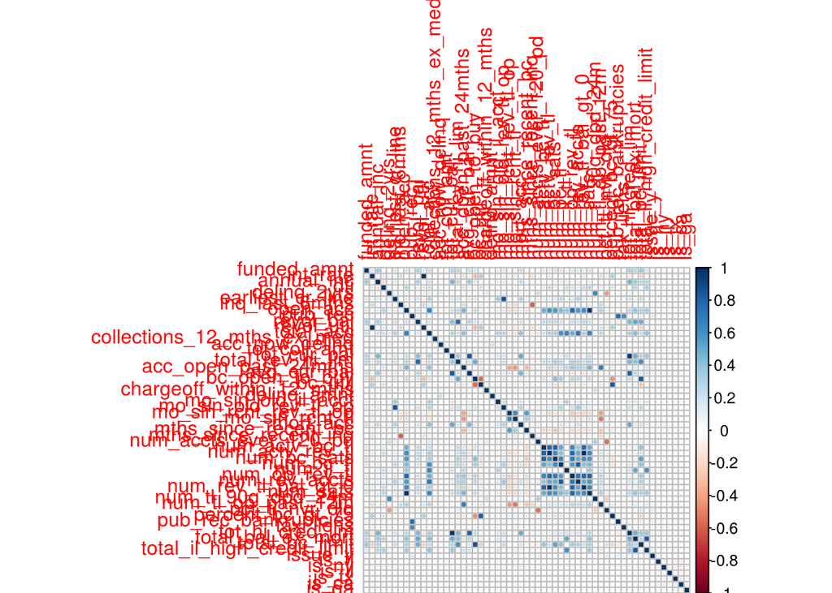

```r
corrplot(cor(data1[getNumericColumns(data1)],use="na.or.complete"))
```

We found some features are quite correlated, we can remove correlated features with `findCorrelation` function. The function will find all correlated pairs that have correlation exceed a specified threshold and try to remove one of them in such a way that overall correlation is reduced.

```r
high_corr <- findCorrelation(cor(data1[getNumericColumns(data1)]), cutoff = .75)
high_corr = getNumericColumns(data1)[high_corr]
high_corr
```

```
##  [1] "num_sats"            "open_acc"            "num_op_rev_tl"
##  [4] "num_rev_accts"       "num_bc_sats"         "total_bc_limit"
##  [7] "num_rev_tl_bal_gt_0" "num_actv_rev_tl"     "tot_hi_cred_lim"
## [10] "total_rev_hi_lim"    "tot_cur_bal"         "total_bal_ex_mort"
## [13] "earliest_cr_line"    "int_rate"            "bc_util"
```

```r
data1 = (data1[,!(names(data1) %in% high_corr)])
```

Let’s look at all numeric features we have left.

```r
str(data1[getNumericColumns(data1)])
```

```
## 'data.frame':    246073 obs. of  42 variables:
##  $ funded_amnt               : int  20800 3000 12000 12000 28000 11100 8000 24000 15000 12000 ...
##  $ annual_inc                : num  81500 25000 40000 96500 325000 90000 33000 100000 98000 60000 ...
##  $ dti                       : num  16.7 24.7 16.9 12.6 18.6 ...
##  $ delinq_2yrs               : int  0 0 0 0 0 1 0 0 0 0 ...
##  $ inq_last_6mths            : int  2 0 0 0 1 0 1 0 2 1 ...
##  $ pub_rec                   : int  0 2 2 0 0 0 1 0 0 0 ...
##  $ revol_bal                 : int  23473 2875 5572 13248 29581 6619 7203 21617 5749 7137 ...
##  $ revol_util                : num  13.53 12.85 13.53 7.62 7.62 ...
##  $ total_acc                 : int  41 26 32 30 31 12 16 39 16 18 ...
##  $ collections_12_mths_ex_med: int  0 0 0 0 0 0 0 0 0 0 ...
##  $ acc_now_delinq            : int  0 0 0 0 0 0 0 0 0 0 ...
##  $ tot_coll_amt              : num  0 154 15386 0 0 ...
##  $ acc_open_past_24mths      : num  9 3 4 4 6 2 2 7 6 8 ...
##  $ avg_cur_bal               : num  869 3906 2268 11783 53306 ...
```

[output cut: 28 more lines]

We transform `annual_inc`, `revol_bal`, `avg_cur_bal`, `bc_open_to_buy`, `total_il_high_credit_limit` by deviding them by `funded_amnt`(amount of loan)

```r
data1$annual_inc = data1$annual_inc/data1$funded_amnt
data1$revol_bal = data1$revol_bal/data1$funded_amnt
data1$avg_cur_bal = data1$avg_cur_bal/data1$funded_amnt
data1$bc_open_to_buy = data1$bc_open_to_buy/data1$funded_amnt
data1$total_il_high_credit_limit = data1$total_il_high_credit_limit/data1$funded_amnt

data1$funded_amnt = NULL
```

Let’s look at all character features we have left.

```r
str(data1[getCharColumns(data1)])
```

```
## 'data.frame':    246073 obs. of  9 variables:
##  $ term               : chr  " 36 months" " 36 months" " 36 months" " 36 months" ...
##  $ sub_grade          : chr  "B5" "B4" "B5" "A3" ...
##  $ emp_length         : chr  "10+ years" "10+ years" "10+ years" "3 years" ...
##  $ home_ownership     : chr  "RENT" "RENT" "RENT" "MORTGAGE" ...
##  $ verification_status: chr  "Verified" "Verified" "Source Verified" "Not Verified" ...
##  $ loan_status        : chr  "Fully Paid" "Fully Paid" "Fully Paid" "Fully Paid" ...
##  $ pymnt_plan         : chr  "n" "n" "n" "n" ...
##  $ purpose            : chr  "debt_consolidation" "debt_consolidation" "debt_consolidation" "debt_consolidation" ...
##  $ initial_list_status: chr  "f" "f" "w" "f" ...
```

We look at `home_ownership` and filter only observations that have value “MORTGAGE”,“OWN”, or “RENT” as these are only values that appear in 2015 data

```r
table(data1$home_ownership)
```

```
##
##      ANY MORTGAGE     NONE    OTHER      OWN     RENT
##        1   123973       40       43    21228   100788
```

```r
data1 = data1 %>% filter(home_ownership == "MORTGAGE" | home_ownership == "OWN" | home_ownership == "RENT")
```

We see there are 3 loans with pymnt_plan=“y”, all ended in being default

```r
data1 %>% filter(pymnt_plan=="y") %>% select(loan_status)
```

```
##   loan_status
## 1     Default
## 2     Default
## 3     Default
```

But 3 loans is too small to make the conclusive finding. We will just remove `pymnt_plan` feature.

```r
data1$pymnt_plan = NULL
```

We will transform all character predictor features to binary dummy variables

```r
loan_status = data1$loan_status
dummy_model = dummyVars(loan_status ~ .,data1,fullRank = TRUE)
data1 = as.data.frame(predict(dummy_model,data1))
data1$loan_status = loan_status
rm(loan_status)

#set loan with status 'Fully Paid' as a positive sample
data1$loan_status = ifelse(data1$loan_status == "Fully Paid","Fully.Paid",data1$loan_status)
data1$loan_status = factor(data1$loan_status,levels = c("Default","Fully.Paid"))
```

The data is centered and scaled. We can try to remove the number of dimensions further by fitting Logistic regression and investigate p-value of the coefficients. The null hypothesis is that each feature makes no contribution to the predictive model(its coefficient is zero). We then discard each feature that fails to reject the hypothesis.

```r
trans_model = preProcess(data1,method=c("center","scale"))
data1 = predict(trans_model, data1)

model = lrm(loan_status ~ .,data1)
model
```

```
##
## Logistic Regression Model
##
## lrm(formula = loan_status ~ ., data = data1)
##                        Model Likelihood     Discrimination    Rank Discrim.
##                           Ratio Test            Indexes          Indexes
## Obs         245989    LR chi2   24375.03    R2       0.147    C       0.714
##  Default     52032    d.f.           103    g        0.968    Dxy     0.428
##  Fully.Paid 193957    Pr(> chi2) <0.0001    gr       2.632    gamma   0.430
## max |deriv|  7e-11                          gp       0.142    tau-a   0.143
##                                             Brier    0.150
##
##                                    Coef    S.E.   Wald Z Pr(>|Z|)
## Intercept                           1.5087 0.0059 255.30 <0.0001
## term 60 months                     -0.2062 0.0061 -34.04 <0.0001
## sub_gradeA2                        -0.0644 0.0142  -4.53 <0.0001
## sub_gradeA3                        -0.1097 0.0145  -7.57 <0.0001
## sub_gradeA4                        -0.1864 0.0163 -11.45 <0.0001
## sub_gradeA5                        -0.2593 0.0173 -15.00 <0.0001
## sub_gradeB1                        -0.3310 0.0185 -17.89 <0.0001
## sub_gradeB2                        -0.4134 0.0210 -19.70 <0.0001
## sub_gradeB3                        -0.5064 0.0235 -21.55 <0.0001
## sub_gradeB4                        -0.5522 0.0237 -23.32 <0.0001
## sub_gradeB5                        -0.5411 0.0218 -24.83 <0.0001
## sub_gradeC1                        -0.5974 0.0233 -25.67 <0.0001
## sub_gradeC2                        -0.6219 0.0235 -26.51 <0.0001
## sub_gradeC3                        -0.6453 0.0233 -27.69 <0.0001
## sub_gradeC4                        -0.6569 0.0234 -28.06 <0.0001
## sub_gradeC5                        -0.6666 0.0233 -28.59 <0.0001
## sub_gradeD1                        -0.6597 0.0230 -28.67 <0.0001
## sub_gradeD2                        -0.6445 0.0223 -28.91 <0.0001
## sub_gradeD3                        -0.6108 0.0214 -28.58 <0.0001
## sub_gradeD4                        -0.6266 0.0213 -29.47 <0.0001
## sub_gradeD5                        -0.5803 0.0200 -29.07 <0.0001
## sub_gradeE1                        -0.5178 0.0177 -29.29 <0.0001
## sub_gradeE2                        -0.5465 0.0183 -29.83 <0.0001
## sub_gradeE3                        -0.4929 0.0170 -29.07 <0.0001
## sub_gradeE4                        -0.4856 0.0166 -29.30 <0.0001
## sub_gradeE5                        -0.4608 0.0157 -29.36 <0.0001
## sub_gradeF1                        -0.4137 0.0146 -28.42 <0.0001
```

[output cut: 62 more lines]

```
## num_bc_tl                           0.0279 0.0097   2.88 0.0040
## num_il_tl                           0.0168 0.0099   1.70 0.0894
## num_tl_90g_dpd_24m                  0.0175 0.0067   2.62 0.0088
## num_tl_op_past_12m                 -0.0088 0.0076  -1.16 0.2462
## pct_tl_nvr_dlq                     -0.0228 0.0070  -3.24 0.0012
## percent_bc_gt_75                   -0.0766 0.0065 -11.73 <0.0001
## pub_rec_bankruptcies                0.0391 0.0118   3.32 0.0009
## tax_liens                           0.0090 0.0097   0.92 0.3550
## total_il_high_credit_limit          0.0721 0.0098   7.36 <0.0001
## is_fl                              -0.0178 0.0052  -3.42 0.0006
## is_ny                              -0.0284 0.0053  -5.34 <0.0001
## is_il                               0.0130 0.0054   2.39 0.0166
## is_tx                               0.0375 0.0055   6.77 <0.0001
## is_ca                               0.0402 0.0057   7.09 <0.0001
## is_ga                               0.0181 0.0054   3.34 0.0008
```

We set our two-tailed p-value cutoff at 0.01, we discard features with p-value exceed this threshold.

```r
tmp = as.data.frame(anova(model))
tmp$feature = rownames(tmp)
tmp = tmp %>% filter(P > 0.01) %>% select(feature,P)
tmp
```

```
##                        feature          P
## 1             emp_length1 year 0.79109580
## 2            emp_length2 years 0.97486100
## 3            emp_length3 years 0.78255500
## 4            emp_length4 years 0.82290650
## 5            emp_length5 years 0.69167559
## 6            emp_length6 years 0.03454150
## 7            emp_length7 years 0.94254322
## 8            emp_length8 years 0.02648818
## 9  verification_statusVerified 0.28497122
## 10          purposecredit_card 0.52436187
## 11   purposedebt_consolidation 0.70902630
## 12     purposehome_improvement 0.03161482
## 13                purposehouse 0.98894832
## 14       purposemajor_purchase 0.06951881
```

[output cut: 16 more lines]

```r
data1 = (data1[,!(names(data1) %in% tmp$feature)])

rm(model,tmp)
```

Some feature names are invalid, replace invalid characters with “_"

```r
colnames(data1) = str_replace_all(colnames(data1)," ","_")
colnames(data1) = str_replace_all(colnames(data1),"<","_")
colnames(data1) = str_replace_all(colnames(data1),"/","_")
```

We then create function to apply all of the above feature engineering:

```r
#derived from str_c("'",paste(colnames(data1),collapse="','"),"'")
#kept_column = colnames(data1)
kept_column = c('term_60_months','sub_gradeA2','sub_gradeA3','sub_gradeA4','sub_gradeA5','sub_gradeB1','sub_gradeB2','sub_gradeB3','sub_gradeB4','sub_gradeB5','sub_gradeC1','sub_gradeC2','sub_gradeC3','sub_gradeC4','sub_gradeC5','sub_gradeD1','sub_gradeD2','sub_gradeD3','sub_gradeD4','sub_gradeD5','sub_gradeE1','sub_gradeE2','sub_gradeE3','sub_gradeE4','sub_gradeE5','sub_gradeF1','sub_gradeF2','sub_gradeF3','sub_gradeF4','sub_gradeF5','sub_gradeG1','sub_gradeG2','sub_gradeG3','sub_gradeG4','sub_gradeG5','emp_length__1_year','emp_length9_years','emp_lengthn_a','home_ownershipOWN','home_ownershipRENT','annual_inc','verification_statusSource_Verified','purposemedical','purposemoving','purposeother','purposesmall_business','purposewedding','dti','delinq_2yrs','inq_last_6mths','revol_util','total_acc','acc_open_past_24mths','avg_cur_bal','bc_open_to_buy','mo_sin_old_il_acct','mo_sin_old_rev_tl_op','mo_sin_rcnt_tl','mort_acc','mths_since_recent_bc','num_accts_ever_120_pd','num_actv_bc_tl','num_bc_tl','num_tl_90g_dpd_24m','pct_tl_nvr_dlq','percent_bc_gt_75','pub_rec_bankruptcies','total_il_high_credit_limit','is_fl','is_ny','is_tx','is_ca','is_ga','loan_status')

applyFeatureEngineering <- function(dt,use_kept_column = kept_column,use_median_impute_model=median_impute_model,  use_dummy_model=dummy_model,use_trans_model=trans_model){

    #consolidate loan status
    dt$loan_status = ifelse(str_detect(dt$loan_status,"Paid"),dt$loan_status,"Default")
    #parse int_rate
    dt$int_rate = (as.numeric(gsub(pattern = "%",replacement = "",x = dt$int_rate)))
    #impute median
    dt = predict(median_impute_model,dt)
    #parse revol_util
    dt$revol_util = (as.numeric(gsub(pattern = "%",replacement = "",x = dt$int_rate)))
    #binary variables for addr_state
    dt$is_fl = ifelse(dt$addr_state=="FL",1,0)
    dt$is_ny = ifelse(dt$addr_state=="NY",1,0)

    dt$is_il = ifelse(dt$addr_state=="IL",1,0)
    dt$is_tx = ifelse(dt$addr_state=="TX",1,0)
    dt$is_ca = ifelse(dt$addr_state=="CA",1,0)
    dt$is_ga = ifelse(dt$addr_state=="GA",1,0)
    #transform transactions
    dt$annual_inc = dt$annual_inc/dt$funded_amnt
    dt$revol_bal = dt$revol_bal/dt$funded_amnt
    dt$avg_cur_bal = dt$avg_cur_bal/dt$funded_amnt
    dt$bc_open_to_buy = dt$bc_open_to_buy/dt$funded_amnt
    dt$total_il_high_credit_limit = dt$total_il_high_credit_limit/dt$funded_amnt
    #if purpose falling outside of recognized values
    all_purpose = c('debt_consolidation','small_business','other','credit_card','major_purchase','moving','home_improvement','house','car','medical','renewable_energy','vacation','wedding')
    dt$purpose = ifelse(dt$purpose %in% all_purpose,dt$purpose,"other")
    #create dummy variables
    loan_status = dt$loan_status
    dt = as.data.frame(predict(use_dummy_model,dt))
    dt$loan_status = loan_status
    #center,scale data
    dt = predict(use_trans_model, dt)
    #remove all unused features
    colnames(dt) = str_replace_all(colnames(dt)," ","_")
    colnames(dt) = str_replace_all(colnames(dt),"<","_")
    colnames(dt) = str_replace_all(colnames(dt),"/","_")
    dt = dt[use_kept_column]

    #set loan with status 'Fully Paid' as a positive sample
    dt$loan_status = ifelse(dt$loan_status == "Fully Paid","Fully.Paid",dt$loan_status)
    dt$loan_status = factor(dt$loan_status,levels = c("Default","Fully.Paid"))

    return(dt)
}
```

# Model Training

We need to determine which performance metric we want to focus on. We load the 2015 test dataset and apply feature engineering procedure.

```r
test_data = read.csv("loan_2015.extract.csv",stringsAsFactors=FALSE)
#later used for evaluate investment
test_data_grade = test_data$grade
test_data_funded_amnt = test_data$funded_amnt
test_data_total_pymnt = test_data$total_pymnt

test_data = applyFeatureEngineering(test_data)
```

The loan data typically have a higher proportion of good loans. We can achieve high accuracy just by labeling all loans as `Fully Paid`

```r
100*nrow(test_data %>% filter(loan_status=="Fully.Paid"))/nrow(test_data)
```

```
## [1] 72.29722
```

For our test data, we gain 72.3% accuracy by just following the above strategy. Recall that we yet to include the outcome of `Current` loans. In a real situation, the ratio of `Fully Paid` loans is usually much higher so accuracy metric is not our main concern here. We instead focus on a trade-off in identifying a default loan as an expense of mislabelling some good loans. We will look at ROC curve and pay particular focus on AUC when we train our models.

Because there is a disproportion of the target variable, we downsampling the Fully Paid loans to be equal to Default loans. This method tends to work well and run faster than upsampling or cost-sensitive training.

Noted that at the end, we aim to stack the results of various learning models(Logistic Regression,SVM,RandomForest, and XGB). Since the downside of downsampling is that information of majority class is discarded, we will continue to make a new downsampling data when we feed it to each model along the way. We anticipate that better result can be obtained by stacking all 4 models since it gets more information from the majority class.

## Logistic Regression

We tune Logistic Regression to our training dataset. We use Elastic Net regularization, which comprised of Ridge and Lasso regularization, with cross-validation to prevent overfitting. Our goal is maximizing AUC.

Due to limited computation resource, we run model tunning on small data and fixed lambda parameter. We use small fold: 3-fold cross validation. We then refit the best model with the whole data.  
(Noted:we put the final tuning result here instead of running through the whole process. We disable the execution of tuning code although readers can enable it back by setting `eval` = TRUE )

```r
set.seed(100)
samp = downSample(data1[-getIndexsOfColumns(data1, c( "loan_status") )],data1$loan_status,yname="loan_status")
#choose small data for tuning
train_index = createDataPartition(samp$loan_status,p = 0.05,list=FALSE,times=1)
```

```r
#run tuning in parallel using available computing cores(you may need to change this)
registerDoMC(cores = 4)

ctrl <- trainControl(method = "cv",
    summaryFunction = twoClassSummary,
    classProbs = TRUE,
    number = 3
    )

glmnGrid = expand.grid(.alpha = seq(0, 1, length = 10), .lambda = 0.01)

glmnTuned = train(samp[train_index,-getIndexsOfColumns(samp,"loan_status")],y = samp[train_index,"loan_status"],method = "glmnet",tuneGrid = glmnGrid,metric = "ROC",trControl = ctrl)
```

```r
plot(glmnTuned)
glmnTuned
```

```r
model = glmnet(
    x = as.matrix(samp[-getIndexsOfColumns(samp,"loan_status")]),
    y=samp$loan_status,
    alpha = 0.7777778,
    lambda = 0.01,
    family = "binomial",
    standardize = FALSE)
```

The finalized Logistic Regression model is applied to the 2015 loan data. We look at ROC graph and AUC. We also set probability prediction cutoff at 50%(noted that the higher this value is, the more likely the loan is `Fully Paid`) and collect some performance metrics for a later comparison.

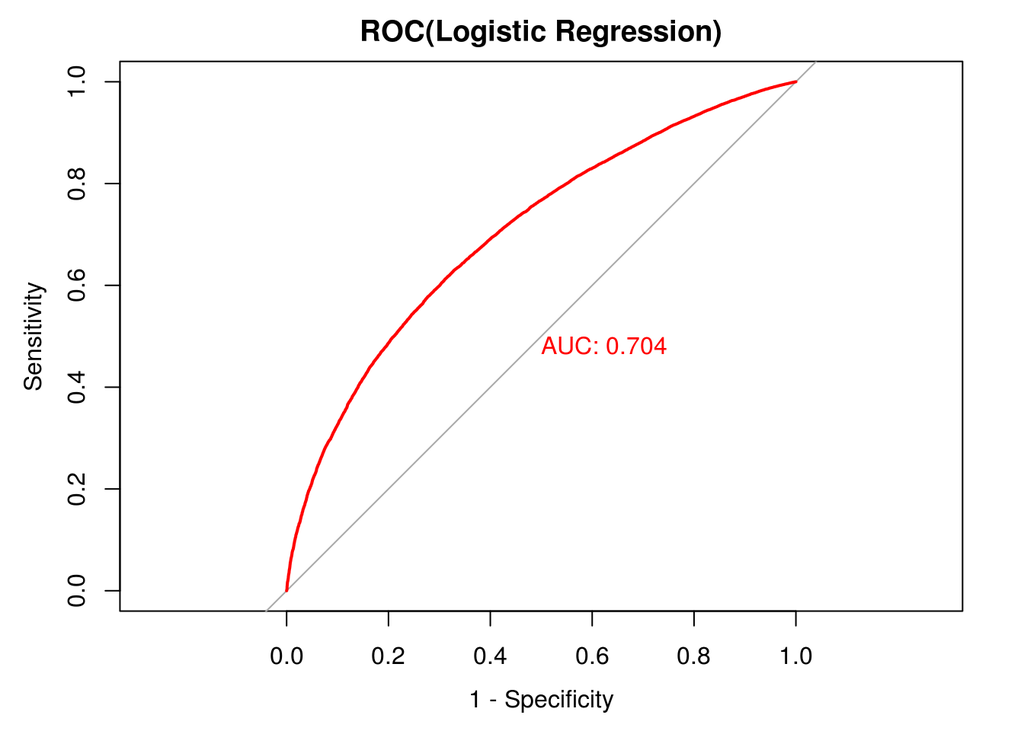

```
##
## Call:
## roc.default(response = test_data$loan_status, predictor = predict_loan_status_logit)
##
## Data: predict_loan_status_logit in 18716 controls (test_data$loan_status Default) < 48844 cases (test_data$loan_status Fully.Paid).
## Area under the curve: 0.7042
```

```r
#data frame for collect model's performance
table_perf = data.frame(model=character(0),
                        auc=numeric(0),
                        accuracy=numeric(0),
                        sensitivity=numeric(0),
                        specificity=numeric(0),
                        kappa=numeric(0),
                        stringsAsFactors = FALSE
                        )

predict_loan_status_logit = predict(model,newx = as.matrix(test_data[-getIndexsOfColumns(test_data,"loan_status")]),type="response")

rocCurve_logit = roc(response = test_data$loan_status,
               predictor = predict_loan_status_logit)
auc_curve = auc(rocCurve_logit)

plot(rocCurve_logit,legacy.axes = TRUE,print.auc = TRUE,col="red",main="ROC(Logistic Regression)")
```

```r
#make a prediction on 50% cutoff
predict_loan_status_label = ifelse(predict_loan_status_logit<0.5,"Default","Fully.Paid")
c = confusionMatrix(predict_loan_status_label,test_data$loan_status,positive="Fully.Paid")

table_perf[1,] = c("logistic regression",
  round(auc_curve,3),
  as.numeric(round(c$overall["Accuracy"],3)),
  as.numeric(round(c$byClass["Sensitivity"],3)),
  as.numeric(round(c$byClass["Specificity"],3)),
  as.numeric(round(c$overall["Kappa"],3))
  )
rm(samp,train_index)
```

The model’s performance is as follow

```r
tail(table_perf,1)
```

```
##                 model   auc accuracy sensitivity specificity kappa
## 1 logistic regression 0.704    0.643       0.636       0.662 0.251
```

## SVM

For SVM, we use Radial Basis as a kernel function. Due to limited computation reason, we use 5% of downsampling data for tunning parameter and 10% of downsampling data for training.

```r
set.seed(200)
#down sampling again so than we get more info when stacking
samp = downSample(data1[-getIndexsOfColumns(data1, c( "loan_status") )],data1$loan_status,yname="loan_status")
#choose small data for tuning
train_index_tuning = createDataPartition(samp$loan_status,p = 0.05,list=FALSE,times=1)
#choose small data for re-train
train_index_training = createDataPartition(samp$loan_status,p = 0.1,list=FALSE,times=1)
```

```r
svmGrid = expand.grid(
                .sigma = as.numeric(sigest(loan_status ~.,data = samp[train_index_tuning,],scaled=FALSE)),
                .C = c(0.1,1,10)
                )

svmTuned = train(
    samp[train_index_tuning,-getIndexsOfColumns(samp,"loan_status")],
    y = samp[train_index_tuning,"loan_status"],
    method = "svmRadial",
    tuneGrid = svmGrid,
    metric = "ROC",
    trControl = ctrl,
    preProcess = NULL,
    scaled = FALSE,
    fit = FALSE)

plot(svmTuned)

svmTuned
```

The best parameter for the model is `sigma` = 0.003909534, and `C` = 0.1. We use this values to fit the 10% of downsampling data and collect its performance based on test set.

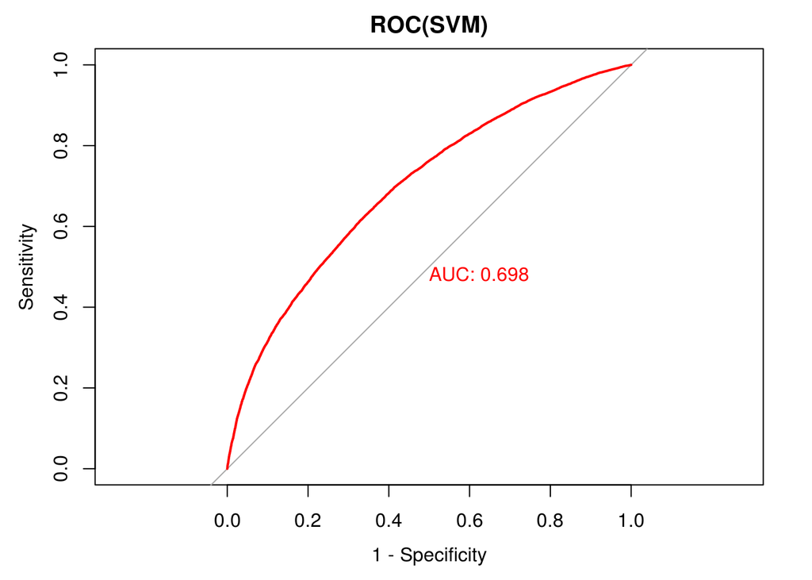

```
##
## Call:
## roc.default(response = test_data$loan_status, predictor = predict_loan_status_svm)
##
## Data: predict_loan_status_svm in 18716 controls (test_data$loan_status Default) < 48844 cases (test_data$loan_status Fully.Paid).
## Area under the curve: 0.6976
```

```r
svm_model = ksvm(loan_status ~ .,
                 data = samp[train_index_training,],
                 kernel = "rbfdot",
                 kpar = list(sigma=0.003909534),
                 C = 0.1,
                 prob.model = TRUE,
                 scaled = FALSE)

predict_loan_status_svm = predict(svm_model,test_data,type="probabilities")
predict_loan_status_svm = as.data.frame(predict_loan_status_svm)$Fully.Paid

rocCurve_svm = roc(response = test_data$loan_status,
               predictor = predict_loan_status_svm)

auc_curve = auc(rocCurve_svm)

plot(rocCurve_svm,legacy.axes = TRUE,print.auc = TRUE,col="red",main="ROC(SVM)")
```

```r
predict_loan_status_label = ifelse(predict_loan_status_svm<0.5,"Default","Fully.Paid")
c = confusionMatrix(predict_loan_status_label,test_data$loan_status,positive="Fully.Paid")
```

This is the summary of model’s performance

```r
table_perf[2,] = c("SVM",
  round(auc_curve,3),
  as.numeric(round(c$overall["Accuracy"],3)),
  as.numeric(round(c$byClass["Sensitivity"],3)),
  as.numeric(round(c$byClass["Specificity"],3)),
  as.numeric(round(c$overall["Kappa"],3))
  )

tail(table_perf,1)
```

```
##   model   auc accuracy sensitivity specificity kappa
## 2   SVM 0.698    0.592       0.536       0.739 0.213
```

## RandomForest

Now, we tune RandomForest model. Like SVM, we tune parameter based on 5% downsampling data.

```r
set.seed(300)
#down sampling again so than we get more info when stacking
samp = downSample(data1[-getIndexsOfColumns(data1, c( "loan_status") )],data1$loan_status,yname="loan_status")
#choose small data for tuning
train_index_tuning = createDataPartition(samp$loan_status,p = 0.05,list=FALSE,times=1)
#choose small data for re-train
train_index_training = createDataPartition(samp$loan_status,p = 0.1,list=FALSE,times=1)
```

```r
rfGrid = expand.grid(
                .mtry = as.integer(seq(2,ncol(samp), (ncol(samp) - 2)/4))
                )

rfTuned = train(
    samp[train_index_tuning,-getIndexsOfColumns(samp,"loan_status")],
    y = samp[train_index_tuning,"loan_status"],
    method = "rf",
    tuneGrid = rfGrid,
    metric = "ROC",
    trControl = ctrl,
    preProcess = NULL,
    ntree = 100
    )

plot(rfTuned)

rfTuned
```

The best parameter is `mtry`(number of predictors) = 2. Like SVM, we fit 10% of downsampling data with this value.

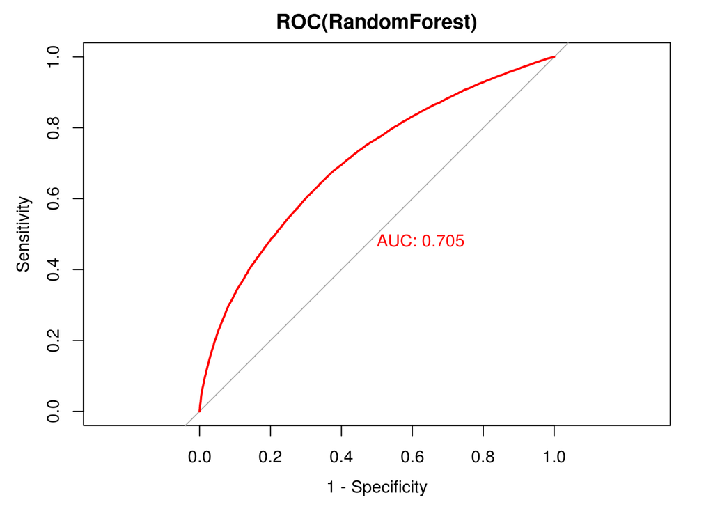

```
##
## Call:
## roc.default(response = test_data$loan_status, predictor = predict_loan_status_rf)
##
## Data: predict_loan_status_rf in 18716 controls (test_data$loan_status Default) < 48844 cases (test_data$loan_status Fully.Paid).
## Area under the curve: 0.7046
```

```r
rf_model = randomForest(loan_status ~ . ,data = samp[train_index_training,],mtry = 2,ntree=400)

predict_loan_status_rf = predict(rf_model,test_data,"prob")
predict_loan_status_rf = as.data.frame(predict_loan_status_rf)$Fully.Paid

rocCurve_rf = roc(response = test_data$loan_status,
               predictor = predict_loan_status_rf)

auc_curve = auc(rocCurve_rf)

plot(rocCurve_rf,legacy.axes = TRUE,print.auc = TRUE,col="red",main="ROC(RandomForest)")
```

```r
predict_loan_status_label = ifelse(predict_loan_status_rf<0.5,"Default","Fully.Paid")
c = confusionMatrix(predict_loan_status_label,test_data$loan_status,positive="Fully.Paid")

table_perf[3,] = c("RandomForest",
  round(auc_curve,3),
  as.numeric(round(c$overall["Accuracy"],3)),
  as.numeric(round(c$byClass["Sensitivity"],3)),
  as.numeric(round(c$byClass["Specificity"],3)),
  as.numeric(round(c$overall["Kappa"],3))
  )
```

The model’s performance is as follow

```r
tail(table_perf,1)
```

```
##          model   auc accuracy sensitivity specificity kappa
## 3 RandomForest 0.705    0.638       0.622       0.679  0.25
```

## Extreme Gradient Boosting

Extreme Gradient Boosting has a very efficient implementation. Unlike SVM and RandomForest, we can tune parameter using the whole downsampling set. We focus on varying Ridge & Lasso regularization and learning rate. We use 10% of data for validating tuning parameter.

```r
set.seed(400)
#down sampling again so than we get more info when stacking
samp = downSample(data1[-getIndexsOfColumns(data1, c( "loan_status") )],data1$loan_status,yname="loan_status")
#choose small data for validating
train_index_tuning= createDataPartition(samp$loan_status,p = 0.1,list=FALSE,times=1)
```

```r
etas = c(0.1,0.3)
alphas = c(0,0.5,1)
lambdas = c(0,0.5,1)

test_watchlist = list(
    test = xgb.DMatrix(
        data = as.matrix(samp[train_index_tuning,][getNumericColumns(samp)]),
        label = as.numeric(samp[train_index_tuning,"loan_status"])-1
    )
)

gbm_perf = data.frame(eta=numeric(0),alpha=numeric(0),lambda=numeric(0),auc=numeric(0))
for(eta in etas){
    for(alpha in alphas){
        for(lambda in lambdas){
            model = xgb.train(
                data= xgb.DMatrix(
                    data = as.matrix(samp[-train_index_tuning,][getNumericColumns(samp)]),
                    label = as.numeric(samp[-train_index_tuning,"loan_status"])-1
                ),
                objective = "binary:logistic",
                nrounds = 350,
                watchlist = test_watchlist,
                eval_metric = "auc",
                early.stop.round = 10,
                alpha = alpha,
                lambda = lambda,
                eta = eta)
            gbm_perf[nrow(gbm_perf)+1,] = c(eta,alpha,lambda,model$bestScore)
        }
    }
}

gbm_perf %>% arrange(desc(auc))
```

The best tuning parameter is `eta` = 0.1, `alpha` = 0.5, and `lambda` = 1.0. We retrain it again here in case readers didn’t run the tuning code. We collect its performance.

```r
set.seed(400)
test_watchlist = list(
    test = xgb.DMatrix(
        data = as.matrix(samp[train_index_tuning,][getNumericColumns(samp)]),
        label = as.numeric(samp[train_index_tuning,"loan_status"])-1
    )
)

xgb_model = xgb.train(
                data= xgb.DMatrix(
                    data = as.matrix(samp[-train_index_tuning,][getNumericColumns(samp)]),
                    label = as.numeric(samp[-train_index_tuning,"loan_status"])-1
                ),
                objective = "binary:logistic",
                nrounds = 350,
                watchlist = test_watchlist,
                eval_metric = "auc",
                early.stop.round = 10,
                alpha = 0.5,
                lambda = 1.0,
                eta = 0.1)
```

```
## Stopping. Best iteration: 136
```

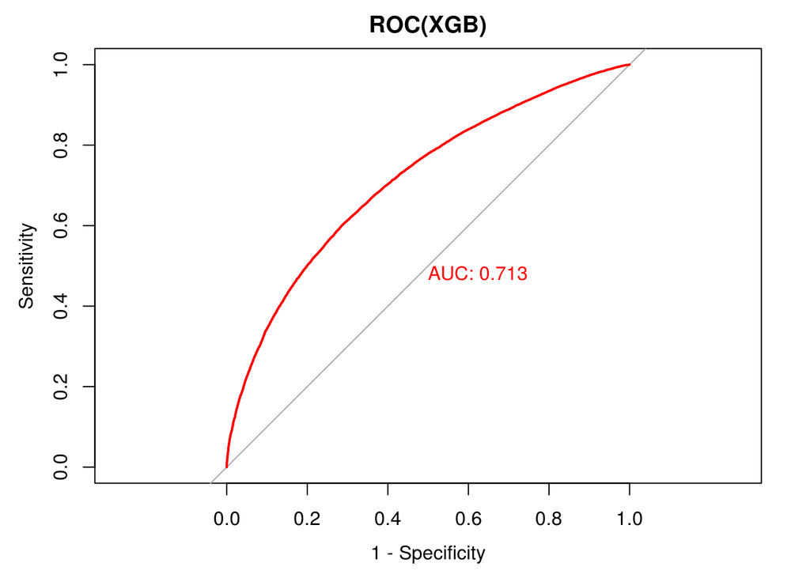

```
##
## Call:
## roc.default(response = test_data$loan_status, predictor = predict_loan_status_xgb)
##
## Data: predict_loan_status_xgb in 18716 controls (test_data$loan_status Default) < 48844 cases (test_data$loan_status Fully.Paid).
## Area under the curve: 0.7128
```

```r
predict_loan_status_xgb = predict(xgb_model,as.matrix(test_data[getNumericColumns(test_data)]))

rocCurve_xgb = roc(response = test_data$loan_status,
               predictor = predict_loan_status_xgb)

auc_curve = auc(rocCurve_xgb)

plot(rocCurve_xgb,legacy.axes = TRUE,print.auc = TRUE,col="red",main="ROC(XGB)")
```

```r
predict_loan_status_label = ifelse(predict_loan_status_xgb<0.5,"Default","Fully.Paid")
c = confusionMatrix(predict_loan_status_label,test_data$loan_status,positive="Fully.Paid")

table_perf[4,] = c("XGB",
  round(auc_curve,3),
  as.numeric(round(c$overall["Accuracy"],3)),
  as.numeric(round(c$byClass["Sensitivity"],3)),
  as.numeric(round(c$byClass["Specificity"],3)),
  as.numeric(round(c$overall["Kappa"],3))
  )
```

The model’s performance is as follow

```r
tail(table_perf,1)
```

```
##   model   auc accuracy sensitivity specificity kappa
## 4   XGB 0.713    0.607       0.549       0.759 0.239
```

## Averaging Ensemble

Our final model is to combine the result of previous machine learning models and provide a single prediction by averaging probabilities from all previous models.

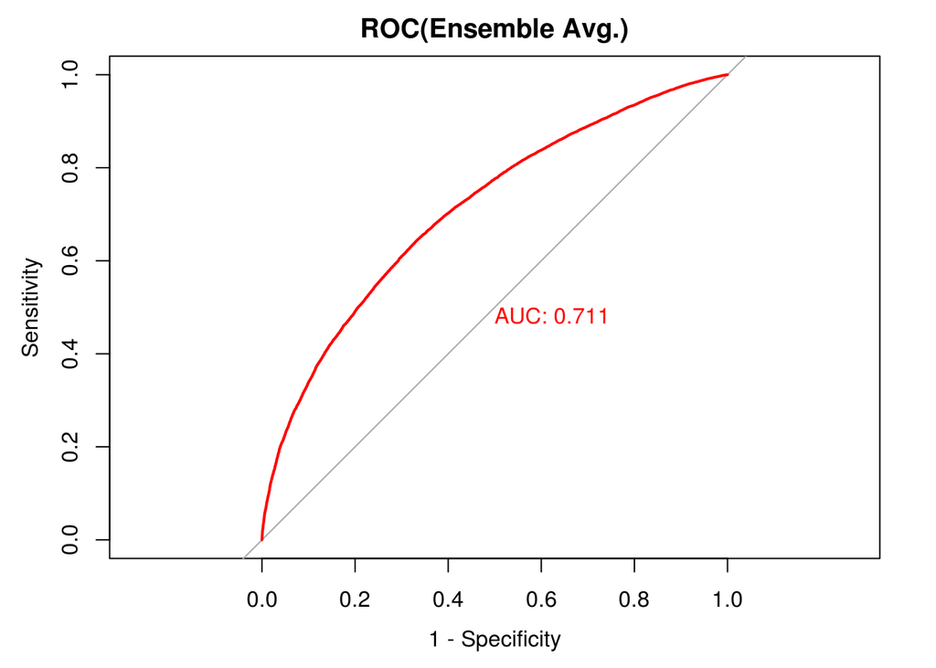

```
##
## Call:
## roc.default(response = test_data$loan_status, predictor = predict_loan_status_ensemble)
##
## Data: predict_loan_status_ensemble in 18716 controls (test_data$loan_status Default) < 48844 cases (test_data$loan_status Fully.Paid).
## Area under the curve: 0.7113
```

```r
predict_loan_status_ensemble = predict_loan_status_logit +
                               predict_loan_status_svm +
                               predict_loan_status_rf +
                               predict_loan_status_xgb

predict_loan_status_ensemble = predict_loan_status_ensemble / 4

rocCurve_ensemble = roc(response = test_data$loan_status,
               predictor = predict_loan_status_ensemble)
auc_curve = auc(rocCurve_ensemble)

plot(rocCurve_ensemble,legacy.axes = TRUE,print.auc = TRUE,col="red",main="ROC(Ensemble Avg.)")
```

```r
predict_loan_status_label = ifelse(predict_loan_status_ensemble<0.5,"Default","Fully.Paid")
c = confusionMatrix(predict_loan_status_label,test_data$loan_status,positive="Fully.Paid")

table_perf[5,] = c("Ensemble",
  round(auc_curve,3),
  as.numeric(round(c$overall["Accuracy"],3)),
  as.numeric(round(c$byClass["Sensitivity"],3)),
  as.numeric(round(c$byClass["Specificity"],3)),
  as.numeric(round(c$overall["Kappa"],3))
  )
```

We get the following performance

```r
tail(table_perf,1)
```

```
##      model   auc accuracy sensitivity specificity kappa
## 5 Ensemble 0.711    0.623       0.586        0.72 0.246
```

# Model Comparison

AUC for each model and their performance when we set probability cutoff at 50% is summarised below

```r
table_perf
```

```
##                 model   auc accuracy sensitivity specificity kappa
## 1 logistic regression 0.704    0.643       0.636       0.662 0.251
## 2                 SVM 0.698    0.592       0.536       0.739 0.213
## 3        RandomForest 0.705    0.638       0.622       0.679  0.25
## 4                 XGB 0.713    0.607       0.549       0.759 0.239
## 5            Ensemble 0.711    0.623       0.586        0.72 0.246
```

```r
plot(rocCurve_logit,legacy.axes = TRUE,col="red",main="ROC compare")
```

```
##
## Call:
## roc.default(response = test_data$loan_status, predictor = predict_loan_status_logit)
##
## Data: predict_loan_status_logit in 18716 controls (test_data$loan_status Default) < 48844 cases (test_data$loan_status Fully.Paid).
## Area under the curve: 0.7042
```

```r
plot(rocCurve_svm,legacy.axes = TRUE,col="blue",add=TRUE)
```

```
##
## Call:
## roc.default(response = test_data$loan_status, predictor = predict_loan_status_svm)
##
## Data: predict_loan_status_svm in 18716 controls (test_data$loan_status Default) < 48844 cases (test_data$loan_status Fully.Paid).
## Area under the curve: 0.6976
```

```r
plot(rocCurve_rf,legacy.axes = TRUE,col="green",add=TRUE)
```

```
##
## Call:
## roc.default(response = test_data$loan_status, predictor = predict_loan_status_rf)
##
## Data: predict_loan_status_rf in 18716 controls (test_data$loan_status Default) < 48844 cases (test_data$loan_status Fully.Paid).
## Area under the curve: 0.7046
```

```r
plot(rocCurve_xgb,legacy.axes = TRUE,col="orange",add=TRUE)
```

```
##
## Call:
## roc.default(response = test_data$loan_status, predictor = predict_loan_status_xgb)
##
## Data: predict_loan_status_xgb in 18716 controls (test_data$loan_status Default) < 48844 cases (test_data$loan_status Fully.Paid).
## Area under the curve: 0.7128
```

```r
plot(rocCurve_ensemble,legacy.axes = TRUE,col="black",add=TRUE)
```

```
##
## Call:
## roc.default(response = test_data$loan_status, predictor = predict_loan_status_ensemble)
##
## Data: predict_loan_status_ensemble in 18716 controls (test_data$loan_status Default) < 48844 cases (test_data$loan_status Fully.Paid).
## Area under the curve: 0.7113
```

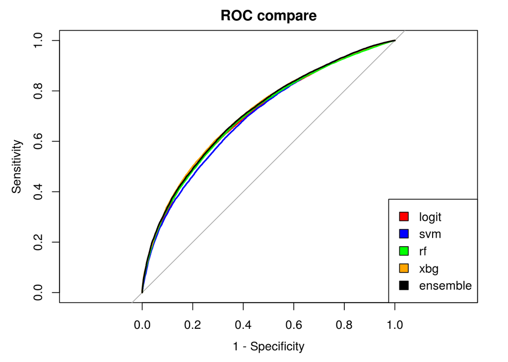

```r
legend("bottomright",legend=c("logit","svm","rf","xbg","ensemble"),fill=c("red","blue","green","orange","black"))
```

Kappa statistics from all models exceed 20% by just small amount, which indicated that they perform moderately better than chance. XGB takes advantage of receiving all downsampling data and provides highest AUC. Comparing performance across models may not be valid, though, because we use different downsampling data for each model. Ensemble model doesn’t improve AUC as we expected.

We are surprised to find that Logistic regression does provide a very competitive performance. At 50% cutoff, it yields reasonable compromise between the percentage of correctly identified good loans(Sensitivity) and bad loans(Specificity) while not sacrificing Accuracy too much(recall that the naive strategy yields 72.3% accuracy). SVM with RBF kernel has lowest AUC. We can train it with only some portion of data as time complexity of the model rapidly jump up. RandomForest yields a comparable result to Logistic Regression. XGB sacrifices Sensitivity rate for Specificity(ability to recall bad loans). It may be suitable if we really want to avoid default loans. Ensemble model does tune up XGB a little bit. Given the simplicity of Logistic Regression model, and ROC graphs are, overall, not significantly difference, we recommend it as a model of choice for predicting LendingClub dataset.

We can calculate investment performance assumed that we follow each model predictions based on 50% cutoff:

```r
#assign the features back for evaluation
test_data$grade = test_data_grade
test_data$funded_amnt = test_data_funded_amnt
test_data$total_pymnt = test_data_total_pymnt

#logistic regression
test_data$prediction =  ifelse(predict_loan_status_logit<0.5,"Default","Fully Paid")
logit_table = createPerformanceTable(test_data)

#SVM
test_data$prediction =  ifelse(predict_loan_status_svm<0.5,"Default","Fully Paid")
svm_table = createPerformanceTable(test_data)

#rf
test_data$prediction =  ifelse(predict_loan_status_rf<0.5,"Default","Fully Paid")
rf_table = createPerformanceTable(test_data)

#XGB
test_data$prediction =  ifelse(predict_loan_status_xgb<0.5,"Default","Fully Paid")
xgb_table = createPerformanceTable(test_data)

#ensemble
test_data$prediction =  ifelse(predict_loan_status_ensemble<0.5,"Default","Fully Paid")
ensemble_table = createPerformanceTable(test_data)
```

For Logistic Regression:

```r
logit_table
```

```
##   grade         roi percent_pick
## 1     A -0.02868136   99.9407513
## 2     B -0.07712652   94.1537468
## 3     C -0.11730945   60.4015616
## 4     D -0.14398647   18.4491764
## 5     E -0.12421653    2.1814007
## 6     F -0.16091886    0.1059322
## 7     G  0.00000000    0.0000000
## 8   ALL -0.08203923   55.3463588
```

For SVM:

```r
svm_table
```

```
##   grade         roi percent_pick
## 1     A -0.02842189  99.43121223
## 2     B -0.08390121  99.15374677
## 3     C -0.11470667  36.73883283
## 4     D  0.01494777   0.77139413
## 5     E  0.09743927   0.05102692
## 6     F  0.00000000   0.00000000
## 7     G  0.00000000   0.00000000
## 8   ALL -0.07477126  46.01243339
```

For RandomForest:

```r
rf_table
```

```
##   grade         roi percent_pick
## 1     A -0.02860544  100.0000000
## 2     B -0.08057145   97.6227390
## 3     C -0.11395171   59.3570958
## 4     D -0.09056090    8.0112495
## 5     E -0.13019485    1.6456181
## 6     F -0.28616990    0.6002825
## 7     G  0.06104822    0.3740648
## 8   ALL -0.07832291   53.8839550
```

For XGB:

```r
xgb_table
```

```
##   grade         roi percent_pick
## 1     A -0.02755103   99.0046214
## 2     B -0.06683685   84.5994832
## 3     C -0.08522953   38.6807281
## 4     D -0.10742489   14.2868622
## 5     E -0.11417002    5.2940426
## 6     F -0.10204509    1.5889831
## 7     G -0.09492406    0.6234414
## 8   ALL -0.06275065   46.3632327
```

For Ensemble model:

```r
ensemble_table
```

```
##   grade         roi percent_pick
## 1     A -0.02857455  99.97630051
## 2     B -0.07905501  96.93798450
## 3     C -0.09891564  47.92881407
## 4     D -0.07386266   7.11128967
## 5     E -0.06045371   0.98226815
## 6     F -0.42870486   0.07062147
## 7     G  0.00000000   0.00000000
## 8   ALL -0.07069706  50.11841326
```

Our baseline strategy:

```r
baseline_table
```

```
##   grade         roi percent_pick
## 1     A -0.02860544          100
## 2     B -0.08447862          100
## 3     C -0.16181754          100
## 4     D -0.23565662          100
## 5     E -0.28144831          100
## 6     F -0.34315720          100
## 7     G -0.35786380          100
## 8   ALL -0.17560423          100
```

We can visualize returns for each model:

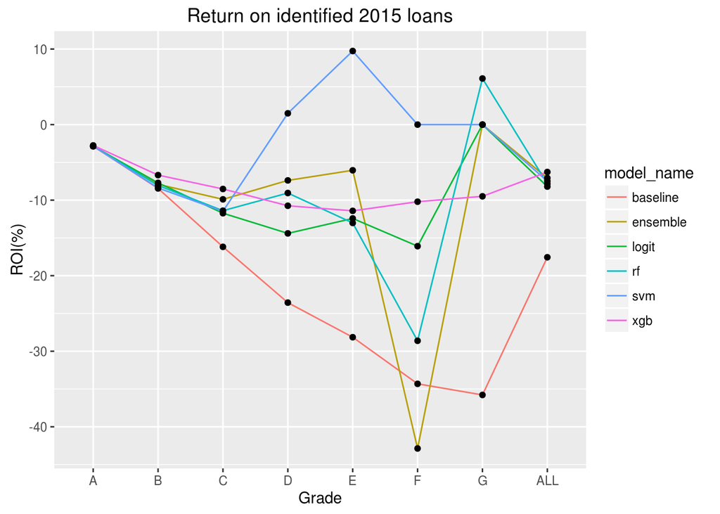

```r
logit_table$model_name = "logit"
svm_table$model_name = "svm"
rf_table$model_name = "rf"
xgb_table$model_name = "xgb"
ensemble_table$model_name = "ensemble"
baseline_table$model_name = "baseline"

full_table = rbind(logit_table,svm_table,rf_table,xgb_table,ensemble_table,baseline_table)

ggplot(full_table,aes(x=grade,y=roi*100,group=model_name)) +
    geom_line(aes(colour = model_name)) +
    geom_point() +
    xlab("Grade") +
    ylab("ROI(%)") +
    labs(title = "Return on identified 2015 loans")
```

and percentage of loans for each grade they picked:

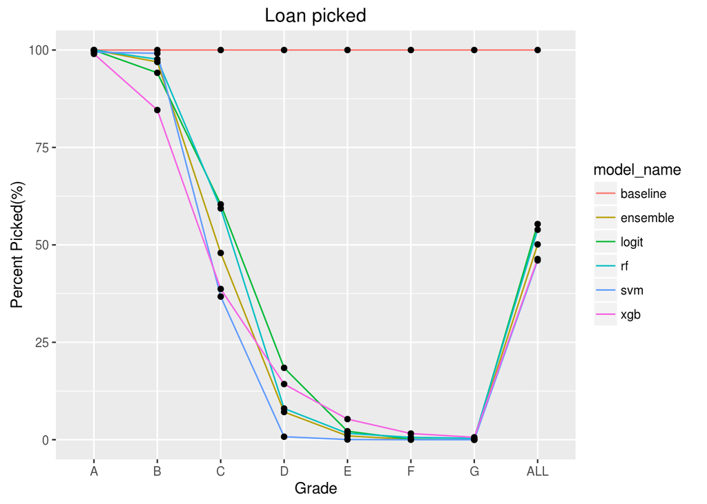

```r
ggplot(full_table,aes(x=grade,y=percent_pick,group=model_name)) +
    geom_line(aes(colour = model_name)) +
    geom_point() +
    xlab("Grade") +
    ylab("Percent Picked(%)") +
    labs(title = "Loan picked")
```

All 5 prediction models beat the benchmark strategy in nearly very aspects. Though they did so for low-grade loans by selecting virtually none. Percentage of loan picked by SVM taper off very fast for D, E, F, G grades. It has high Specificity(ability to recall default) so it might be best to use against riskier loans. Many models do shine on predicting middle rate- B, C, D grade - loans, as their ROI is significantly higher than the baseline’s, and still have sizable investment.

# Conclusion

Determining the loan outcome, like many financial predictions, is clearly not an easy task. Our models barely go above 20% Kappa Statistics which indicates that chance still played a large role here. They also penalized low-grade loans so much that they rather not select anythings, and thus prevent us from reaping benefits of higher interest rate. Our finding nevertheless shows a promising venue in loan prediction, as higher-than-average ROI can still be gained on certain loan quality. A further analysis may incorporate some discarded features, such as `emp_title`, or external information, like relevant economic status, into the model.